# Risk Factor Analysis

## Outcome Variable

**Outcome Variable:** ever_wasted

## Predictor Variables

**Intervention Variable:** single

**Adjustment Set:**

- arm
- W_mage
- meducyrs
- feducyrs
- W_mhtcm
- W_mwtkg
- W_mbmi
- delta_W_mage
- delta_meducyrs
- delta_feducyrs
- delta_W_mhtcm
- delta_W_mwtkg
- delta_W_mbmi

## Stratifying Variables

The analysis was stratified on these variable(s):

- agecat
- studyid
- country

## Data Summary

| agecat | studyid | country | single | ever_wasted | n_cell | n |
| --- | --- | --- | --- | --- | --- | --- |
| 0-24 months | ki0047075b-MAL-ED | BANGLADESH | 0 | 0 | 176 | 263 |
| 0-24 months | ki0047075b-MAL-ED | BANGLADESH | 0 | 1 | 87 | 263 |
| 0-24 months | ki0047075b-MAL-ED | BANGLADESH | 1 | 0 | 0 | 263 |
| 0-24 months | ki0047075b-MAL-ED | BANGLADESH | 1 | 1 | 0 | 263 |
| 0-24 months | ki0047075b-MAL-ED | BRAZIL | 0 | 0 | 182 | 233 |
| 0-24 months | ki0047075b-MAL-ED | BRAZIL | 0 | 1 | 15 | 233 |
| 0-24 months | ki0047075b-MAL-ED | BRAZIL | 1 | 0 | 31 | 233 |
| 0-24 months | ki0047075b-MAL-ED | BRAZIL | 1 | 1 | 5 | 233 |
| 0-24 months | ki0047075b-MAL-ED | INDIA | 0 | 0 | 130 | 249 |
| 0-24 months | ki0047075b-MAL-ED | INDIA | 0 | 1 | 119 | 249 |
| 0-24 months | ki0047075b-MAL-ED | INDIA | 1 | 0 | 0 | 249 |
| 0-24 months | ki0047075b-MAL-ED | INDIA | 1 | 1 | 0 | 249 |
| 0-24 months | ki0047075b-MAL-ED | NEPAL | 0 | 0 | 166 | 240 |
| 0-24 months | ki0047075b-MAL-ED | NEPAL | 0 | 1 | 74 | 240 |
| 0-24 months | ki0047075b-MAL-ED | NEPAL | 1 | 0 | 0 | 240 |
| 0-24 months | ki0047075b-MAL-ED | NEPAL | 1 | 1 | 0 | 240 |
| 0-24 months | ki0047075b-MAL-ED | PERU | 0 | 0 | 247 | 302 |
| 0-24 months | ki0047075b-MAL-ED | PERU | 0 | 1 | 21 | 302 |
| 0-24 months | ki0047075b-MAL-ED | PERU | 1 | 0 | 28 | 302 |
| 0-24 months | ki0047075b-MAL-ED | PERU | 1 | 1 | 6 | 302 |
| 0-24 months | ki0047075b-MAL-ED | SOUTH AFRICA | 0 | 0 | 142 | 312 |
| 0-24 months | ki0047075b-MAL-ED | SOUTH AFRICA | 0 | 1 | 34 | 312 |
| 0-24 months | ki0047075b-MAL-ED | SOUTH AFRICA | 1 | 0 | 106 | 312 |
| 0-24 months | ki0047075b-MAL-ED | SOUTH AFRICA | 1 | 1 | 30 | 312 |
| 0-24 months | ki0047075b-MAL-ED | TANZANIA, UNITED REPUBLIC OF | 0 | 0 | 218 | 261 |
| 0-24 months | ki0047075b-MAL-ED | TANZANIA, UNITED REPUBLIC OF | 0 | 1 | 33 | 261 |
| 0-24 months | ki0047075b-MAL-ED | TANZANIA, UNITED REPUBLIC OF | 1 | 0 | 7 | 261 |
| 0-24 months | ki0047075b-MAL-ED | TANZANIA, UNITED REPUBLIC OF | 1 | 1 | 3 | 261 |
| 0-24 months | ki1066203-TanzaniaChild2 | TANZANIA, UNITED REPUBLIC OF | 0 | 0 | 1643 | 2375 |
| 0-24 months | ki1066203-TanzaniaChild2 | TANZANIA, UNITED REPUBLIC OF | 0 | 1 | 508 | 2375 |

[output cut: 150 more lines]

The following strata were considered:

- agecat: 0-24 months, studyid: ki0047075b-MAL-ED, country: BANGLADESH
- agecat: 0-24 months, studyid: ki0047075b-MAL-ED, country: BRAZIL
- agecat: 0-24 months, studyid: ki0047075b-MAL-ED, country: INDIA
- agecat: 0-24 months, studyid: ki0047075b-MAL-ED, country: NEPAL
- agecat: 0-24 months, studyid: ki0047075b-MAL-ED, country: PERU
- agecat: 0-24 months, studyid: ki0047075b-MAL-ED, country: SOUTH AFRICA
- agecat: 0-24 months, studyid: ki0047075b-MAL-ED, country: TANZANIA, UNITED REPUBLIC OF
- agecat: 0-24 months, studyid: ki1066203-TanzaniaChild2, country: TANZANIA, UNITED REPUBLIC OF
- agecat: 0-24 months, studyid: ki1112895-Guatemala BSC, country: GUATEMALA
- agecat: 0-24 months, studyid: ki1119695-PROBIT, country: BELARUS
- agecat: 0-24 months, studyid: ki1126311-ZVITAMBO, country: ZIMBABWE
- agecat: 0-24 months, studyid: ki1135781-COHORTS, country: GUATEMALA
- agecat: 0-24 months, studyid: ki1135781-COHORTS, country: INDIA
- agecat: 0-24 months, studyid: ki1135781-COHORTS, country: PHILIPPINES
- agecat: 0-24 months, studyid: kiGH5241-JiVitA-4, country: BANGLADESH
- agecat: 0-6 months, studyid: ki0047075b-MAL-ED, country: BANGLADESH
- agecat: 0-6 months, studyid: ki0047075b-MAL-ED, country: BRAZIL
- agecat: 0-6 months, studyid: ki0047075b-MAL-ED, country: INDIA
- agecat: 0-6 months, studyid: ki0047075b-MAL-ED, country: NEPAL
- agecat: 0-6 months, studyid: ki0047075b-MAL-ED, country: PERU
- agecat: 0-6 months, studyid: ki0047075b-MAL-ED, country: SOUTH AFRICA
- agecat: 0-6 months, studyid: ki0047075b-MAL-ED, country: TANZANIA, UNITED REPUBLIC OF
- agecat: 0-6 months, studyid: ki1066203-TanzaniaChild2, country: TANZANIA, UNITED REPUBLIC OF
- agecat: 0-6 months, studyid: ki1112895-Guatemala BSC, country: GUATEMALA
- agecat: 0-6 months, studyid: ki1119695-PROBIT, country: BELARUS
- agecat: 0-6 months, studyid: ki1126311-ZVITAMBO, country: ZIMBABWE
- agecat: 0-6 months, studyid: ki1135781-COHORTS, country: GUATEMALA
- agecat: 0-6 months, studyid: ki1135781-COHORTS, country: INDIA
- agecat: 0-6 months, studyid: ki1135781-COHORTS, country: PHILIPPINES
- agecat: 0-6 months, studyid: kiGH5241-JiVitA-4, country: BANGLADESH
- agecat: 6-24 months, studyid: ki0047075b-MAL-ED, country: BANGLADESH
- agecat: 6-24 months, studyid: ki0047075b-MAL-ED, country: BRAZIL
- agecat: 6-24 months, studyid: ki0047075b-MAL-ED, country: INDIA
- agecat: 6-24 months, studyid: ki0047075b-MAL-ED, country: NEPAL
- agecat: 6-24 months, studyid: ki0047075b-MAL-ED, country: PERU
- agecat: 6-24 months, studyid: ki0047075b-MAL-ED, country: SOUTH AFRICA
- agecat: 6-24 months, studyid: ki0047075b-MAL-ED, country: TANZANIA, UNITED REPUBLIC OF
- agecat: 6-24 months, studyid: ki1066203-TanzaniaChild2, country: TANZANIA, UNITED REPUBLIC OF
- agecat: 6-24 months, studyid: ki1112895-Guatemala BSC, country: GUATEMALA
- agecat: 6-24 months, studyid: ki1119695-PROBIT, country: BELARUS
- agecat: 6-24 months, studyid: ki1126311-ZVITAMBO, country: ZIMBABWE
- agecat: 6-24 months, studyid: ki1135781-COHORTS, country: GUATEMALA
- agecat: 6-24 months, studyid: ki1135781-COHORTS, country: INDIA
- agecat: 6-24 months, studyid: ki1135781-COHORTS, country: PHILIPPINES
- agecat: 6-24 months, studyid: kiGH5241-JiVitA-4, country: BANGLADESH

### Dropped Strata

Some strata were dropped due to rare outcomes:

- agecat: 0-24 months, studyid: ki0047075b-MAL-ED, country: BANGLADESH
- agecat: 0-24 months, studyid: ki0047075b-MAL-ED, country: INDIA
- agecat: 0-24 months, studyid: ki0047075b-MAL-ED, country: NEPAL
- agecat: 0-24 months, studyid: ki0047075b-MAL-ED, country: TANZANIA, UNITED REPUBLIC OF
- agecat: 0-24 months, studyid: ki1112895-Guatemala BSC, country: GUATEMALA
- agecat: 0-24 months, studyid: ki1135781-COHORTS, country: INDIA
- agecat: 0-24 months, studyid: kiGH5241-JiVitA-4, country: BANGLADESH
- agecat: 0-6 months, studyid: ki0047075b-MAL-ED, country: BANGLADESH
- agecat: 0-6 months, studyid: ki0047075b-MAL-ED, country: BRAZIL
- agecat: 0-6 months, studyid: ki0047075b-MAL-ED, country: INDIA
- agecat: 0-6 months, studyid: ki0047075b-MAL-ED, country: NEPAL
- agecat: 0-6 months, studyid: ki0047075b-MAL-ED, country: PERU
- agecat: 0-6 months, studyid: ki0047075b-MAL-ED, country: TANZANIA, UNITED REPUBLIC OF
- agecat: 0-6 months, studyid: ki1112895-Guatemala BSC, country: GUATEMALA
- agecat: 0-6 months, studyid: ki1135781-COHORTS, country: INDIA
- agecat: 0-6 months, studyid: kiGH5241-JiVitA-4, country: BANGLADESH
- agecat: 6-24 months, studyid: ki0047075b-MAL-ED, country: BANGLADESH
- agecat: 6-24 months, studyid: ki0047075b-MAL-ED, country: BRAZIL
- agecat: 6-24 months, studyid: ki0047075b-MAL-ED, country: INDIA
- agecat: 6-24 months, studyid: ki0047075b-MAL-ED, country: NEPAL
- agecat: 6-24 months, studyid: ki0047075b-MAL-ED, country: PERU
- agecat: 6-24 months, studyid: ki0047075b-MAL-ED, country: TANZANIA, UNITED REPUBLIC OF
- agecat: 6-24 months, studyid: ki1112895-Guatemala BSC, country: GUATEMALA
- agecat: 6-24 months, studyid: ki1119695-PROBIT, country: BELARUS
- agecat: 6-24 months, studyid: ki1135781-COHORTS, country: INDIA
- agecat: 6-24 months, studyid: kiGH5241-JiVitA-4, country: BANGLADESH

## Methods Detail

We’re interested in the causal parameters $E[Y_a]$ for all values of $a \in \mathcal{A}$. These parameters represent the mean outcome if, possibly contrary to fact, we intervened to set all units to have $A=a$. Under the randomization and positivity assumptions, these are identified by the statistical parameters $\psi_a=E_W[E_{Y|A,W}(Y|A=a,W)]$. In addition, we’re interested in the mean of $Y$, $E[Y]$ under no intervention (the observed mean). We will estimate these parameters by using SuperLearner to fit the relevant likelihood factors – $E_{Y|A,W}(Y|A=a,W)$ and $p(A=a|W)$, and then updating our likelihood fit using a joint TMLE.

For unadjusted analyses ($W=\{\}$), initial likelihoods were estimated using Lrnr_glm to estimate the simple $E(Y|A)$ and Lrnr_mean to estimate $p(A)$. For adjusted analyses, a small library containing Lrnr_glmnet, Lrnr_xgboost, and Lrnr_mean was used.

Having estimated these parameters, we will then use the delta method to estimate relative risks and attributable risks relative to a prespecified baseline level of $A$.

# Results Detail

## Results Plots

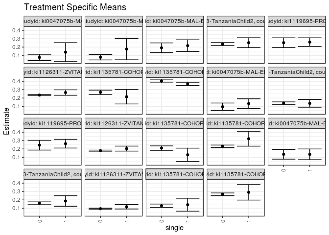

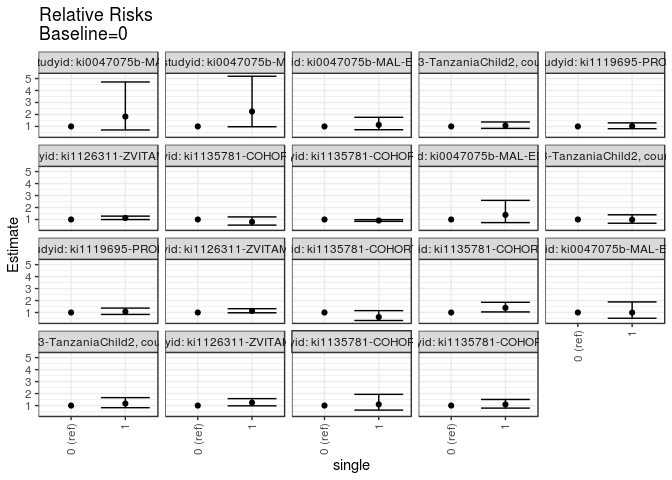

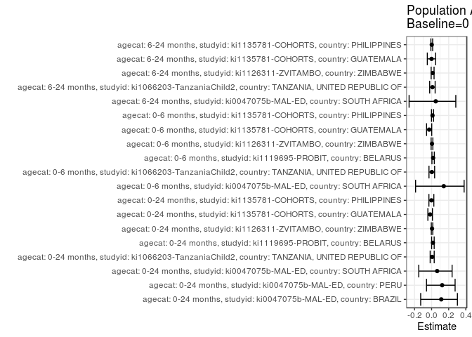

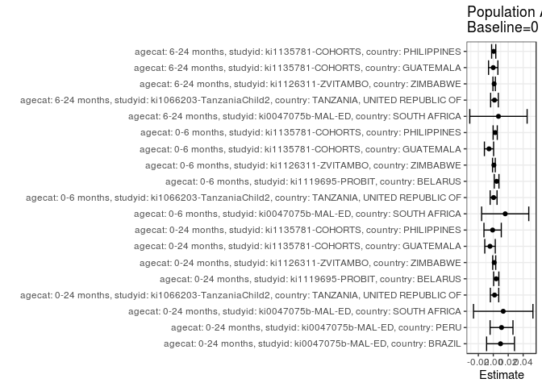

## Results Table

### Parameter: TSM

| agecat | studyid | country | intervention_level | baseline_level | estimate | ci_lower | ci_upper |
| --- | --- | --- | --- | --- | --- | --- | --- |
| 0-24 months | ki0047075b-MAL-ED | BRAZIL | 0 | NA | 0.0761421 | 0.0390259 | 0.1132584 |
| 0-24 months | ki0047075b-MAL-ED | BRAZIL | 1 | NA | 0.1388889 | 0.0256764 | 0.2521013 |
| 0-24 months | ki0047075b-MAL-ED | PERU | 0 | NA | 0.0783582 | 0.0461309 | 0.1105855 |
| 0-24 months | ki0047075b-MAL-ED | PERU | 1 | NA | 0.1764706 | 0.0481180 | 0.3048232 |
| 0-24 months | ki0047075b-MAL-ED | SOUTH AFRICA | 0 | NA | 0.1918093 | 0.1334971 | 0.2501215 |
| 0-24 months | ki0047075b-MAL-ED | SOUTH AFRICA | 1 | NA | 0.2170702 | 0.1471054 | 0.2870350 |
| 0-24 months | ki1066203-TanzaniaChild2 | TANZANIA, UNITED REPUBLIC OF | 0 | NA | 0.2353487 | 0.2174187 | 0.2532786 |
| 0-24 months | ki1066203-TanzaniaChild2 | TANZANIA, UNITED REPUBLIC OF | 1 | NA | 0.2524417 | 0.1931515 | 0.3117320 |
| 0-24 months | ki1119695-PROBIT | BELARUS | 0 | NA | 0.2526313 | 0.1943525 | 0.3109101 |
| 0-24 months | ki1119695-PROBIT | BELARUS | 1 | NA | 0.2595661 | 0.2084768 | 0.3106555 |
| 0-24 months | ki1126311-ZVITAMBO | ZIMBABWE | 0 | NA | 0.2351990 | 0.2278709 | 0.2425270 |
| 0-24 months | ki1126311-ZVITAMBO | ZIMBABWE | 1 | NA | 0.2654762 | 0.2331968 | 0.2977557 |
| 0-24 months | ki1135781-COHORTS | GUATEMALA | 0 | NA | 0.2683733 | 0.2421505 | 0.2945962 |
| 0-24 months | ki1135781-COHORTS | GUATEMALA | 1 | NA | 0.2151960 | 0.1286812 | 0.3017109 |
| 0-24 months | ki1135781-COHORTS | PHILIPPINES | 0 | NA | 0.4035478 | 0.3818537 | 0.4252420 |
| 0-24 months | ki1135781-COHORTS | PHILIPPINES | 1 | NA | 0.3686815 | 0.3487935 | 0.3885695 |
| 0-6 months | ki0047075b-MAL-ED | SOUTH AFRICA | 0 | NA | 0.0962094 | 0.0522565 | 0.1401623 |
| 0-6 months | ki0047075b-MAL-ED | SOUTH AFRICA | 1 | NA | 0.1333734 | 0.0760240 | 0.1907227 |
| 0-6 months | ki1066203-TanzaniaChild2 | TANZANIA, UNITED REPUBLIC OF | 0 | NA | 0.1389478 | 0.1243119 | 0.1535837 |
| 0-6 months | ki1066203-TanzaniaChild2 | TANZANIA, UNITED REPUBLIC OF | 1 | NA | 0.1357975 | 0.0899530 | 0.1816419 |
| 0-6 months | ki1119695-PROBIT | BELARUS | 0 | NA | 0.2452979 | 0.1866739 | 0.3039219 |
| 0-6 months | ki1119695-PROBIT | BELARUS | 1 | NA | 0.2632929 | 0.2110682 | 0.3155175 |
| 0-6 months | ki1126311-ZVITAMBO | ZIMBABWE | 0 | NA | 0.1798710 | 0.1732101 | 0.1865318 |
| 0-6 months | ki1126311-ZVITAMBO | ZIMBABWE | 1 | NA | 0.2043206 | 0.1745499 | 0.2340913 |
| 0-6 months | ki1135781-COHORTS | GUATEMALA | 0 | NA | 0.2101124 | 0.1833337 | 0.2368910 |
| 0-6 months | ki1135781-COHORTS | GUATEMALA | 1 | NA | 0.1304348 | 0.0509292 | 0.2099404 |
| 0-6 months | ki1135781-COHORTS | PHILIPPINES | 0 | NA | 0.2311439 | 0.2157668 | 0.2465210 |
| 0-6 months | ki1135781-COHORTS | PHILIPPINES | 1 | NA | 0.3223270 | 0.2334226 | 0.4112314 |
| 6-24 months | ki0047075b-MAL-ED | SOUTH AFRICA | 0 | NA | 0.1359392 | 0.0777658 | 0.1941126 |
| 6-24 months | ki0047075b-MAL-ED | SOUTH AFRICA | 1 | NA | 0.1353002 | 0.0709969 | 0.1996035 |
| 6-24 months | ki1066203-TanzaniaChild2 | TANZANIA, UNITED REPUBLIC OF | 0 | NA | 0.1596397 | 0.1428249 | 0.1764544 |
| 6-24 months | ki1066203-TanzaniaChild2 | TANZANIA, UNITED REPUBLIC OF | 1 | NA | 0.1867138 | 0.1240283 | 0.2493994 |
| 6-24 months | ki1126311-ZVITAMBO | ZIMBABWE | 0 | NA | 0.0948544 | 0.0891097 | 0.1005992 |
| 6-24 months | ki1126311-ZVITAMBO | ZIMBABWE | 1 | NA | 0.1179655 | 0.0906642 | 0.1452667 |
| 6-24 months | ki1135781-COHORTS | GUATEMALA | 0 | NA | 0.1296928 | 0.1089243 | 0.1504612 |
| 6-24 months | ki1135781-COHORTS | GUATEMALA | 1 | NA | 0.1422774 | 0.0648263 | 0.2197285 |
| 6-24 months | ki1135781-COHORTS | PHILIPPINES | 0 | NA | 0.2664715 | 0.2497102 | 0.2832327 |
| 6-24 months | ki1135781-COHORTS | PHILIPPINES | 1 | NA | 0.2906575 | 0.1980347 | 0.3832803 |

### Parameter: E(Y)

| agecat | studyid | country | intervention_level | baseline_level | estimate | ci_lower | ci_upper |
| --- | --- | --- | --- | --- | --- | --- | --- |
| 0-24 months | ki0047075b-MAL-ED | BRAZIL | NA | NA | 0.0858369 | 0.0497913 | 0.1218826 |
| 0-24 months | ki0047075b-MAL-ED | PERU | NA | NA | 0.0894040 | 0.0571706 | 0.1216374 |
| 0-24 months | ki0047075b-MAL-ED | SOUTH AFRICA | NA | NA | 0.2051282 | 0.1602507 | 0.2500058 |
| 0-24 months | ki1066203-TanzaniaChild2 | TANZANIA, UNITED REPUBLIC OF | NA | NA | 0.2370526 | 0.2199455 | 0.2541598 |
| 0-24 months | ki1119695-PROBIT | BELARUS | NA | NA | 0.2565984 | 0.1993515 | 0.3138454 |
| 0-24 months | ki1126311-ZVITAMBO | ZIMBABWE | NA | NA | 0.2364291 | 0.2293629 | 0.2434953 |
| 0-24 months | ki1135781-COHORTS | GUATEMALA | NA | NA | 0.2639933 | 0.2390117 | 0.2889749 |
| 0-24 months | ki1135781-COHORTS | PHILIPPINES | NA | NA | 0.4026622 | 0.3851243 | 0.4202002 |
| 0-6 months | ki0047075b-MAL-ED | SOUTH AFRICA | NA | NA | 0.1121795 | 0.0771053 | 0.1472536 |
| 0-6 months | ki1066203-TanzaniaChild2 | TANZANIA, UNITED REPUBLIC OF | NA | NA | 0.1393684 | 0.1254369 | 0.1532999 |
| 0-6 months | ki1119695-PROBIT | BELARUS | NA | NA | 0.2497780 | 0.1917926 | 0.3077635 |
| 0-6 months | ki1126311-ZVITAMBO | ZIMBABWE | NA | NA | 0.1806915 | 0.1742710 | 0.1871119 |
| 0-6 months | ki1135781-COHORTS | GUATEMALA | NA | NA | 0.2043796 | 0.1788445 | 0.2299146 |
| 0-6 months | ki1135781-COHORTS | PHILIPPINES | NA | NA | 0.2336884 | 0.2185531 | 0.2488237 |
| 6-24 months | ki0047075b-MAL-ED | SOUTH AFRICA | NA | NA | 0.1428571 | 0.1001583 | 0.1855560 |
| 6-24 months | ki1066203-TanzaniaChild2 | TANZANIA, UNITED REPUBLIC OF | NA | NA | 0.1612581 | 0.1451483 | 0.1773679 |
| 6-24 months | ki1126311-ZVITAMBO | ZIMBABWE | NA | NA | 0.0959985 | 0.0904349 | 0.1015621 |
| 6-24 months | ki1135781-COHORTS | GUATEMALA | NA | NA | 0.1296130 | 0.1098539 | 0.1493721 |
| 6-24 months | ki1135781-COHORTS | PHILIPPINES | NA | NA | 0.2670270 | 0.2505637 | 0.2834903 |

### Parameter: RR

| agecat | studyid | country | intervention_level | baseline_level | estimate | ci_lower | ci_upper |
| --- | --- | --- | --- | --- | --- | --- | --- |
| 0-24 months | ki0047075b-MAL-ED | BRAZIL | 0 | 0 | 1.0000000 | 1.0000000 | 1.0000000 |
| 0-24 months | ki0047075b-MAL-ED | BRAZIL | 1 | 0 | 1.8240741 | 0.7056101 | 4.7154176 |
| 0-24 months | ki0047075b-MAL-ED | PERU | 0 | 0 | 1.0000000 | 1.0000000 | 1.0000000 |
| 0-24 months | ki0047075b-MAL-ED | PERU | 1 | 0 | 2.2521008 | 0.9765802 | 5.1935910 |
| 0-24 months | ki0047075b-MAL-ED | SOUTH AFRICA | 0 | 0 | 1.0000000 | 1.0000000 | 1.0000000 |
| 0-24 months | ki0047075b-MAL-ED | SOUTH AFRICA | 1 | 0 | 1.1316979 | 0.7265797 | 1.7626975 |
| 0-24 months | ki1066203-TanzaniaChild2 | TANZANIA, UNITED REPUBLIC OF | 0 | 0 | 1.0000000 | 1.0000000 | 1.0000000 |
| 0-24 months | ki1066203-TanzaniaChild2 | TANZANIA, UNITED REPUBLIC OF | 1 | 0 | 1.0726286 | 0.8381058 | 1.3727767 |
| 0-24 months | ki1119695-PROBIT | BELARUS | 0 | 0 | 1.0000000 | 1.0000000 | 1.0000000 |
| 0-24 months | ki1119695-PROBIT | BELARUS | 1 | 0 | 1.0274505 | 0.8123191 | 1.2995564 |
| 0-24 months | ki1126311-ZVITAMBO | ZIMBABWE | 0 | 0 | 1.0000000 | 1.0000000 | 1.0000000 |
| 0-24 months | ki1126311-ZVITAMBO | ZIMBABWE | 1 | 0 | 1.1287304 | 0.9956475 | 1.2796019 |
| 0-24 months | ki1135781-COHORTS | GUATEMALA | 0 | 0 | 1.0000000 | 1.0000000 | 1.0000000 |
| 0-24 months | ki1135781-COHORTS | GUATEMALA | 1 | 0 | 0.8018533 | 0.5301947 | 1.2127029 |
| 0-24 months | ki1135781-COHORTS | PHILIPPINES | 0 | 0 | 1.0000000 | 1.0000000 | 1.0000000 |
| 0-24 months | ki1135781-COHORTS | PHILIPPINES | 1 | 0 | 0.9136005 | 0.8466876 | 0.9858014 |
| 0-6 months | ki0047075b-MAL-ED | SOUTH AFRICA | 0 | 0 | 1.0000000 | 1.0000000 | 1.0000000 |
| 0-6 months | ki0047075b-MAL-ED | SOUTH AFRICA | 1 | 0 | 1.3862823 | 0.7402633 | 2.5960744 |
| 0-6 months | ki1066203-TanzaniaChild2 | TANZANIA, UNITED REPUBLIC OF | 0 | 0 | 1.0000000 | 1.0000000 | 1.0000000 |
| 0-6 months | ki1066203-TanzaniaChild2 | TANZANIA, UNITED REPUBLIC OF | 1 | 0 | 0.9773274 | 0.6862026 | 1.3919634 |
| 0-6 months | ki1119695-PROBIT | BELARUS | 0 | 0 | 1.0000000 | 1.0000000 | 1.0000000 |
| 0-6 months | ki1119695-PROBIT | BELARUS | 1 | 0 | 1.0733595 | 0.8414846 | 1.3691287 |
| 0-6 months | ki1126311-ZVITAMBO | ZIMBABWE | 0 | 0 | 1.0000000 | 1.0000000 | 1.0000000 |
| 0-6 months | ki1126311-ZVITAMBO | ZIMBABWE | 1 | 0 | 1.1359285 | 0.9774043 | 1.3201636 |
| 0-6 months | ki1135781-COHORTS | GUATEMALA | 0 | 0 | 1.0000000 | 1.0000000 | 1.0000000 |
| 0-6 months | ki1135781-COHORTS | GUATEMALA | 1 | 0 | 0.6207859 | 0.3330396 | 1.1571449 |
| 0-6 months | ki1135781-COHORTS | PHILIPPINES | 0 | 0 | 1.0000000 | 1.0000000 | 1.0000000 |
| 0-6 months | ki1135781-COHORTS | PHILIPPINES | 1 | 0 | 1.3944863 | 1.0499834 | 1.8520216 |
| 6-24 months | ki0047075b-MAL-ED | SOUTH AFRICA | 0 | 0 | 1.0000000 | 1.0000000 | 1.0000000 |
| 6-24 months | ki0047075b-MAL-ED | SOUTH AFRICA | 1 | 0 | 0.9952994 | 0.5255721 | 1.8848431 |
| 6-24 months | ki1066203-TanzaniaChild2 | TANZANIA, UNITED REPUBLIC OF | 0 | 0 | 1.0000000 | 1.0000000 | 1.0000000 |
| 6-24 months | ki1066203-TanzaniaChild2 | TANZANIA, UNITED REPUBLIC OF | 1 | 0 | 1.1695955 | 0.8228608 | 1.6624364 |
| 6-24 months | ki1126311-ZVITAMBO | ZIMBABWE | 0 | 0 | 1.0000000 | 1.0000000 | 1.0000000 |
| 6-24 months | ki1126311-ZVITAMBO | ZIMBABWE | 1 | 0 | 1.2436474 | 0.9792122 | 1.5794930 |
| 6-24 months | ki1135781-COHORTS | GUATEMALA | 0 | 0 | 1.0000000 | 1.0000000 | 1.0000000 |
| 6-24 months | ki1135781-COHORTS | GUATEMALA | 1 | 0 | 1.0970340 | 0.6220945 | 1.9345674 |
| 6-24 months | ki1135781-COHORTS | PHILIPPINES | 0 | 0 | 1.0000000 | 1.0000000 | 1.0000000 |
| 6-24 months | ki1135781-COHORTS | PHILIPPINES | 1 | 0 | 1.0907640 | 0.7883123 | 1.5092573 |

### Parameter: PAR

| agecat | studyid | country | intervention_level | baseline_level | estimate | ci_lower | ci_upper |
| --- | --- | --- | --- | --- | --- | --- | --- |
| 0-24 months | ki0047075b-MAL-ED | BRAZIL | 0 | NA | 0.0096948 | -0.0089432 | 0.0283328 |
| 0-24 months | ki0047075b-MAL-ED | PERU | 0 | NA | 0.0110458 | -0.0042594 | 0.0263510 |
| 0-24 months | ki0047075b-MAL-ED | SOUTH AFRICA | 0 | NA | 0.0133189 | -0.0264683 | 0.0531061 |
| 0-24 months | ki1066203-TanzaniaChild2 | TANZANIA, UNITED REPUBLIC OF | 0 | NA | 0.0017039 | -0.0038883 | 0.0072962 |
| 0-24 months | ki1119695-PROBIT | BELARUS | 0 | NA | 0.0039671 | 0.0004849 | 0.0074493 |
| 0-24 months | ki1126311-ZVITAMBO | ZIMBABWE | 0 | NA | 0.0012301 | -0.0007913 | 0.0032515 |
| 0-24 months | ki1135781-COHORTS | GUATEMALA | 0 | NA | -0.0043800 | -0.0114210 | 0.0026610 |
| 0-24 months | ki1135781-COHORTS | PHILIPPINES | 0 | NA | -0.0008856 | -0.0124889 | 0.0107177 |
| 0-6 months | ki0047075b-MAL-ED | SOUTH AFRICA | 0 | NA | 0.0159701 | -0.0155909 | 0.0475312 |
| 0-6 months | ki1066203-TanzaniaChild2 | TANZANIA, UNITED REPUBLIC OF | 0 | NA | 0.0004207 | -0.0041760 | 0.0050173 |
| 0-6 months | ki1119695-PROBIT | BELARUS | 0 | NA | 0.0044801 | 0.0013699 | 0.0075903 |
| 0-6 months | ki1126311-ZVITAMBO | ZIMBABWE | 0 | NA | 0.0008205 | -0.0010308 | 0.0026718 |
| 0-6 months | ki1135781-COHORTS | GUATEMALA | 0 | NA | -0.0057328 | -0.0119082 | 0.0004426 |
| 0-6 months | ki1135781-COHORTS | PHILIPPINES | 0 | NA | 0.0025445 | -0.0002410 | 0.0053300 |
| 6-24 months | ki0047075b-MAL-ED | SOUTH AFRICA | 0 | NA | 0.0069180 | -0.0314790 | 0.0453149 |
| 6-24 months | ki1066203-TanzaniaChild2 | TANZANIA, UNITED REPUBLIC OF | 0 | NA | 0.0016184 | -0.0035305 | 0.0067674 |
| 6-24 months | ki1126311-ZVITAMBO | ZIMBABWE | 0 | NA | 0.0011441 | -0.0005008 | 0.0027890 |
| 6-24 months | ki1135781-COHORTS | GUATEMALA | 0 | NA | -0.0000798 | -0.0063410 | 0.0061814 |
| 6-24 months | ki1135781-COHORTS | PHILIPPINES | 0 | NA | 0.0005556 | -0.0022393 | 0.0033504 |

### Parameter: PAF

| agecat | studyid | country | intervention_level | baseline_level | estimate | ci_lower | ci_upper |
| --- | --- | --- | --- | --- | --- | --- | --- |
| 0-24 months | ki0047075b-MAL-ED | BRAZIL | 0 | NA | 0.1129442 | -0.1275143 | 0.3021215 |
| 0-24 months | ki0047075b-MAL-ED | PERU | 0 | NA | 0.1235489 | -0.0596047 | 0.2750443 |
| 0-24 months | ki0047075b-MAL-ED | SOUTH AFRICA | 0 | NA | 0.0649296 | -0.1502934 | 0.2398838 |
| 0-24 months | ki1066203-TanzaniaChild2 | TANZANIA, UNITED REPUBLIC OF | 0 | NA | 0.0071880 | -0.0166844 | 0.0304999 |
| 0-24 months | ki1119695-PROBIT | BELARUS | 0 | NA | 0.0154604 | 0.0004747 | 0.0302214 |
| 0-24 months | ki1126311-ZVITAMBO | ZIMBABWE | 0 | NA | 0.0052030 | -0.0033833 | 0.0137158 |
| 0-24 months | ki1135781-COHORTS | GUATEMALA | 0 | NA | -0.0165914 | -0.0435989 | 0.0097172 |
| 0-24 months | ki1135781-COHORTS | PHILIPPINES | 0 | NA | -0.0021993 | -0.0314274 | 0.0262005 |
| 0-6 months | ki0047075b-MAL-ED | SOUTH AFRICA | 0 | NA | 0.1423621 | -0.1872782 | 0.3804798 |
| 0-6 months | ki1066203-TanzaniaChild2 | TANZANIA, UNITED REPUBLIC OF | 0 | NA | 0.0030183 | -0.0305142 | 0.0354597 |
| 0-6 months | ki1119695-PROBIT | BELARUS | 0 | NA | 0.0179364 | 0.0040181 | 0.0316602 |
| 0-6 months | ki1126311-ZVITAMBO | ZIMBABWE | 0 | NA | 0.0045408 | -0.0057570 | 0.0147332 |
| 0-6 months | ki1135781-COHORTS | GUATEMALA | 0 | NA | -0.0280498 | -0.0586145 | 0.0016325 |
| 0-6 months | ki1135781-COHORTS | PHILIPPINES | 0 | NA | 0.0108884 | -0.0011214 | 0.0227542 |
| 6-24 months | ki0047075b-MAL-ED | SOUTH AFRICA | 0 | NA | 0.0484257 | -0.2631761 | 0.2831612 |
| 6-24 months | ki1066203-TanzaniaChild2 | TANZANIA, UNITED REPUBLIC OF | 0 | NA | 0.0100364 | -0.0224094 | 0.0414525 |
| 6-24 months | ki1126311-ZVITAMBO | ZIMBABWE | 0 | NA | 0.0119177 | -0.0053554 | 0.0288941 |
| 6-24 months | ki1135781-COHORTS | GUATEMALA | 0 | NA | -0.0006157 | -0.0501073 | 0.0465434 |
| 6-24 months | ki1135781-COHORTS | PHILIPPINES | 0 | NA | 0.0020805 | -0.0084450 | 0.0124962 |